# Mandatory Vehicle Insurance - Models

Georgina & Zsofia

2025-04-27

1. Data preprocessing
- source: https://github.com/GhodratRezaei/vehicle-Insurance-Classification-
1. Importing the dataset

```r
library(readr)
training_data<- read_csv("C:/Users/Diak/Downloads/Training DataSet.csv")
View(training_data)
```

2. Checking the data types

```r
library(dplyr)
glimpse(training_data)
```

```
Rows: 102,351
Columns: 13
$ id                   <dbl> 1, 2, 3, 4, 5, 6, 7, 8, 9, 10, 11, 12, 13, 14, 15, 16, 17, 18, 19, 20, 21, …
$ Gender               <chr> "Female", "Male", "Male", "Male", "Female", "Female", "Male", "Male", "Fema…
$ Age                  <dbl> 44, 23, 43, 60, 42, 40, 26, 28, 23, 33, 36, 23, 75, 48, 43, 48, 22, 38, 40,…
$ Driving_License      <dbl> 1, 1, 1, 1, 1, 1, 1, 1, 1, 1, 1, 1, 1, 1, 1, 1, 1, 1, 1, 1, 1, 1, 1, 1, 1, …
$ Licence_Type         <chr> "M", "M", "C", "B", "B", "A", "D", "D", "B", "A", "C", "B", "B", "A", "M", …
$ Region_Code          <dbl> 30, 3, 28, 28, 46, 8, 46, 28, 29, 30, 28, 3, 8, 46, 23, 28, 41, 28, 46, 36,…
$ Previously_Insured   <chr> "No", "Yes", "No", "Yes", "No", "No", "Yes", "No", "No", "No", "No", "Yes",…
$ Vehicle_Age          <chr> "1-2 Year", "< 1 Year", "1-2 Year", "1-2 Year", "1-2 Year", "1-2 Year", "< …
$ Vehicle_Damage       <chr> "Yes", "No", "Yes", "No", "Yes", "Yes", "No", "Yes", "Yes", "Yes", "Yes", "…
$ Annual_Premium       <dbl> 25741, 2630, 70720, 48512, 32169, 34092, 22452, 36869, 34853, 27740, 45244,…
$ Policy_Sales_Channel <dbl> 154, 152, 52, 26, 124, 124, 152, 124, 152, 157, 26, 152, 78, 11, 26, 26, 15…
$ Seniority            <dbl> 152, 256, 224, 86, 132, 285, 59, 60, 83, 254, 93, 201, 95, 52, 273, 152, 12…
$ Target               <dbl> 0, 0, 0, 0, 0, 1, 0, 1, 0, 1, 1, 0, 0, 0, 0, 0, 0, 0, 1, 1, 0, 0, 0, 1, 0, …
```

- id: This is only the identifier, so it is not needed for the models.
- Gender: This should be a categorical variable.
- Age: This is a numerical data.
- Driving license: This is a categorical variable and shows if the customer has driving license or not. 1 - has driving license, 0 - does not have driving license
- License type: This is a categorical variable showing the license type.
- Region code: This is a categorical variable showing the region code of the customer.
- Previously insured: This shows if the customer had previously insurance or not, so it is a categorical variable.
- Vehicle age: This is a categorical variable showing the age of the vehicle, for example 1-2 Year or < 1 Year.
- Vehicle Damage: This is a categorical variable, if it is 1 then it indicates that the customer got his or her vehicle damaged previously.
- Annual premium: This is a numerical variable and shows the amount that should be payed yearly.
- Policy sales channel: This is a categorical variable showing the channel, like over mail or phone for example with codes.
- Seniority: This shows the number of days the customer has been associated with the company, it is numerical.
- Target: This is a categorical variable showing if the customer is interested(1) or not(0).

After checking the data types, based on the description the proper types should be set.If it is a categorical variable then factor should be set.

```r
training_data$id <- NULL
factor_variables <- c("Gender","Driving_License","Licence_Type","Region_Code", "Previously_Insured", "Vehicle_Age","Vehicle_Damage","Target","Policy_Sales_Channel")
training_data[factor_variables] <- lapply(training_data[factor_variables], as.factor)
```

3. Checking the missing values.

```r
colSums(is.na(training_data))
```

```
              Gender                  Age      Driving_License         Licence_Type          Region_Code
                   0                    0                    0                 5091                    0
  Previously_Insured          Vehicle_Age       Vehicle_Damage       Annual_Premium Policy_Sales_Channel
                   0                    0                    0                    0                    0
           Seniority               Target
                   0                    0
```

There are 5091 missing values in case of the licence type. There are more kinds of methods for imputing the missing values, however it can introduce biases, so we decided to delete them, since a lot of data will still remain.

```r
training_data <- na.omit(training_data)
```

```r
training_data$Policy_Sales_Channel <- NULL
training_data$Driving_License <- NULL
```

2. Modeling:

For this kind of task, it is a little bit important to use models that are transparent and interpretable. In the context of insurance sales through call centers, understanding which customers are likely to be interested in an offer is crucial.However it is not like deciding about loans as a bank, it is less important here to know all the details, since it is an internal project only, and otherwise someone decides about the order for example or anything else, so why not decide more accurate using models?

We choose the following 3 models (2 is fully interpretable) to test:

- decision tree
- logistic regression
- random forest
1. Train-Test split with stratified split method: 80% - 20%

```r
library(caret)
set.seed(2025)
train<- createDataPartition(training_data$Target, p = 0.8, list = FALSE)

train_split <- training_data[train, ]
test_split  <- training_data[-train, ]

prop.table(table(train_split$Target))
```

```
        0         1
0.6827102 0.3172898
```

```r
prop.table(table(test_split$Target))
```

```
        0         1
0.6827412 0.3172588
```

Here it is also evident that in this dataset around 30% accepted it and 70% rejected the offer.

2. Decision Tree Training

```r
library(rpart)
library(rpart.plot)
```

Creating the most complex model with information gain as criterion:

```r
dt_complex <- rpart(Target ~ .,
                  data = train_split, method = "class", control = rpart.control(cp = 0),parms = list(split = "information"))
```

Checking the complexity parameters to choose an optimized but not too complex model. Here the complexity parameter is chosen based on xerror. After the xerror is not significantly decreasing, we can use that cp.

```r
print("Complexity Parameters:")
```

```
[1] "Complexity Parameters:"
```

```r
print(dt_complex$cptable)
```

```
             CP nsplit rel error    xerror        xstd
1  7.012854e-02      0 1.0000000 1.0000000 0.005258662
2  4.415100e-02      3 0.7896144 0.7896144 0.004895982
3  1.944264e-03      4 0.7454634 0.7462330 0.004803097
4  1.566213e-03      7 0.7385369 0.7448558 0.004800037
5  6.075826e-04     10 0.7338383 0.7400356 0.004789269
6  5.805790e-04     11 0.7332307 0.7434786 0.004796969
7  5.670771e-04     16 0.7295042 0.7429520 0.004795794
8  5.400734e-04     19 0.7278030 0.7427090 0.004795252
9  5.346727e-04     22 0.7261828 0.7427090 0.004795252
10 5.265716e-04     27 0.7235094 0.7427090 0.004795252
11 4.658134e-04     28 0.7229828 0.7427495 0.004795342
12 4.455606e-04     30 0.7220512 0.7421824 0.004794075
13 4.253078e-04     33 0.7207145 0.7421824 0.004794075
14 4.050551e-04     38 0.7182032 0.7424255 0.004794618
```

[output cut: 73 more lines]

Optimal model training

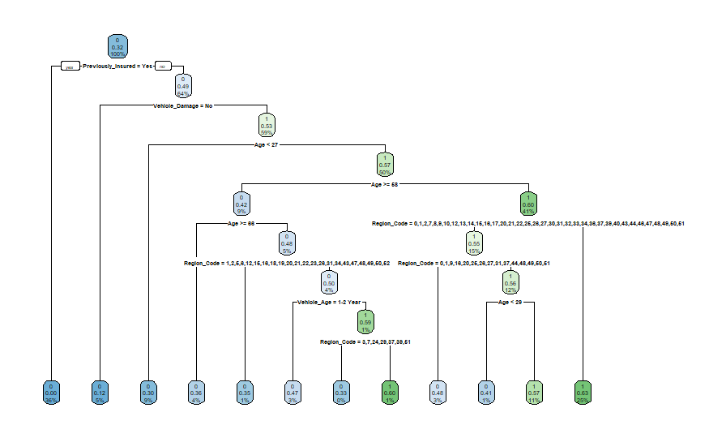

```r
dt_optimal <- rpart(Target ~ .,
                  data = train_split, method = "class", control = rpart.control(cp = 6.075826e-04),parms = list(split = "information"))
rpart.plot(dt_optimal)
```

Checking the performance of the optimal model on testing data:

```r
library(caret)

evaluate_model <- function(true_labels, predicted_labels) {
  cm <- confusionMatrix(predicted_labels, true_labels, positive = "1")
  print(cm)
}

predictions <- predict(dt_optimal, newdata = test_split, type = "class")
evaluate_model(test_split$Target, predictions)
```

```
Confusion Matrix and Statistics

          Reference
Prediction     0     1
         0 10402  1692
         1  2878  4479

               Accuracy : 0.7651
                 95% CI : (0.759, 0.771)
    No Information Rate : 0.6827
    P-Value [Acc > NIR] : < 2.2e-16

                  Kappa : 0.4842

 Mcnemar's Test P-Value : < 2.2e-16

            Sensitivity : 0.7258
            Specificity : 0.7833
         Pos Pred Value : 0.6088
         Neg Pred Value : 0.8601
             Prevalence : 0.3173
         Detection Rate : 0.2303
   Detection Prevalence : 0.3782
      Balanced Accuracy : 0.7545

       'Positive' Class : 1
```

c.Logistic Regression Training:

Basic model training

```r
logistic <- glm(Target ~ ., data = train_split, family = binomial)
logistic
```

```
Call:  glm(formula = Target ~ ., family = binomial, data = train_split)

Coefficients:
          (Intercept)             GenderMale                    Age          Licence_TypeB
           -2.502e+00              1.127e-01             -2.365e-02             -6.136e-02
        Licence_TypeC          Licence_TypeD          Licence_TypeM           Region_Code1
           -6.307e-02             -4.742e-02             -2.708e-02              1.341e-01
         Region_Code2           Region_Code3           Region_Code4           Region_Code5
            3.138e-01              9.072e-01              9.282e-01              5.887e-01
         Region_Code6           Region_Code7           Region_Code8           Region_Code9
            8.008e-01              5.965e-01              5.231e-01              3.582e-01
        Region_Code10          Region_Code11          Region_Code12          Region_Code13
            6.320e-01              1.077e+00              5.881e-01              4.963e-01
        Region_Code14          Region_Code15          Region_Code16          Region_Code17
            7.284e-01              3.280e-01              2.552e-01              4.405e-01
        Region_Code18          Region_Code19          Region_Code20          Region_Code21
            1.080e+00              9.418e-01              2.435e-01              7.268e-01
        Region_Code22          Region_Code23          Region_Code24          Region_Code25
            1.017e-01              1.141e+00              6.771e-01              1.216e-01
        Region_Code26          Region_Code27          Region_Code28          Region_Code29
            7.777e-03              2.441e-01              8.656e-01              1.053e+00
        Region_Code30          Region_Code31          Region_Code32          Region_Code33
            7.397e-01              3.251e-01              6.362e-01              5.901e-01
        Region_Code34          Region_Code35          Region_Code36          Region_Code37
            3.197e-01              1.000e+00              4.540e-01              3.145e-01
        Region_Code38          Region_Code39          Region_Code40          Region_Code41
            8.758e-01              5.569e-01              6.489e-01              9.745e-01
        Region_Code42          Region_Code43          Region_Code44          Region_Code45
            5.223e-01              2.914e-01             -1.748e-02              6.994e-01
        Region_Code46          Region_Code47          Region_Code48          Region_Code49
            6.464e-01              2.425e-01              3.111e-01              1.790e-01
        Region_Code50          Region_Code51          Region_Code52  Previously_InsuredYes
            2.236e-01              5.406e-01              5.850e-01             -4.163e+00
 Vehicle_Age> 2 Years    Vehicle_Age1-2 Year      Vehicle_DamageYes         Annual_Premium
            1.415e+00              1.130e+00              1.959e+00              5.462e-07
            Seniority
           -3.980e-05

Degrees of Freedom: 77808 Total (i.e. Null);  77744 Residual
Null Deviance:      97230
Residual Deviance: 64980    AIC: 65110
```

optimal model training with removing unimportant variables

```r
logistic_backward <- step(logistic, direction = "backward", trace = FALSE)
logistic_backward
```

```
Call:  glm(formula = Target ~ Gender + Age + Region_Code + Previously_Insured +
    Vehicle_Age + Vehicle_Damage, family = binomial, data = train_split)

Coefficients:
          (Intercept)             GenderMale                    Age           Region_Code1
             -2.54888                0.11255               -0.02356                0.13684
         Region_Code2           Region_Code3           Region_Code4           Region_Code5
              0.32648                0.91883                0.93781                0.60127
         Region_Code6           Region_Code7           Region_Code8           Region_Code9
              0.81190                0.61127                0.54057                0.37085
        Region_Code10          Region_Code11          Region_Code12          Region_Code13
              0.64395                1.08766                0.59776                0.50876
        Region_Code14          Region_Code15          Region_Code16          Region_Code17
              0.74081                0.34073                0.26333                0.45501
        Region_Code18          Region_Code19          Region_Code20          Region_Code21
              1.09219                0.95559                0.24312                0.73751
        Region_Code22          Region_Code23          Region_Code24          Region_Code25
              0.11198                1.15079                0.68846                0.13248
        Region_Code26          Region_Code27          Region_Code28          Region_Code29
              0.02124                0.25458                0.88449                1.06644
        Region_Code30          Region_Code31          Region_Code32          Region_Code33
              0.75003                0.32572                0.65008                0.60248
        Region_Code34          Region_Code35          Region_Code36          Region_Code37
              0.33198                1.01224                0.46719                0.32758
        Region_Code38          Region_Code39          Region_Code40          Region_Code41
              0.88518                0.56958                0.66135                0.98864
        Region_Code42          Region_Code43          Region_Code44          Region_Code45
              0.52666                0.30484               -0.01040                0.70923
        Region_Code46          Region_Code47          Region_Code48          Region_Code49
              0.65856                0.25536                0.30889                0.18843
        Region_Code50          Region_Code51          Region_Code52  Previously_InsuredYes
              0.23841                0.56094                0.59780               -4.16236
 Vehicle_Age> 2 Years    Vehicle_Age1-2 Year      Vehicle_DamageYes
              1.41403                1.12791                1.95977

Degrees of Freedom: 77808 Total (i.e. Null);  77750 Residual
Null Deviance:      97230
Residual Deviance: 64980    AIC: 65100
```

testing it on test data

```r
probabilities_lr <- predict(logistic_backward, newdata = test_split, type = "response")
predicted_class_lr <- ifelse(probabilities_lr > 0.5, 1, 0)
evaluate_model(as.factor(test_split$Target), as.factor(predicted_class_lr))
```

```
Confusion Matrix and Statistics

          Reference
Prediction     0     1
         0 10430  1933
         1  2850  4238

               Accuracy : 0.7541
                 95% CI : (0.748, 0.7601)
    No Information Rate : 0.6827
    P-Value [Acc > NIR] : < 2.2e-16

                  Kappa : 0.4541

 Mcnemar's Test P-Value : < 2.2e-16

            Sensitivity : 0.6868
            Specificity : 0.7854
         Pos Pred Value : 0.5979
         Neg Pred Value : 0.8436
             Prevalence : 0.3173
         Detection Rate : 0.2179
   Detection Prevalence : 0.3644
      Balanced Accuracy : 0.7361

       'Positive' Class : 1
```

how the model is deciding?

```r
summary(logistic_backward)
```

```
Call:
glm(formula = Target ~ Gender + Age + Region_Code + Previously_Insured +
    Vehicle_Age + Vehicle_Damage, family = binomial, data = train_split)

Coefficients:
                        Estimate Std. Error z value Pr(>|z|)
(Intercept)           -2.5488752  0.1439603 -17.705  < 2e-16 ***
GenderMale             0.1125479  0.0192785   5.838 5.28e-09 ***
Age                   -0.0235598  0.0009343 -25.217  < 2e-16 ***
Region_Code1           0.1368432  0.2304799   0.594 0.552692
Region_Code2           0.3264815  0.1691500   1.930 0.053591 .
Region_Code3           0.9188284  0.1455852   6.311 2.77e-10 ***
Region_Code4           0.9378110  0.1840142   5.096 3.46e-07 ***
Region_Code5           0.6012669  0.2035739   2.954 0.003141 **
Region_Code6           0.8118953  0.1648477   4.925 8.43e-07 ***
Region_Code7           0.6112749  0.1630686   3.749 0.000178 ***
Region_Code8           0.5405657  0.1360617   3.973 7.10e-05 ***
Region_Code9           0.3708452  0.1776531   2.087 0.036846 *
Region_Code10          0.6439537  0.1762833   3.653 0.000259 ***
Region_Code11          1.0876619  0.1482992   7.334 2.23e-13 ***
Region_Code12          0.5977552  0.1718841   3.478 0.000506 ***
Region_Code13          0.5087613  0.1643340   3.096 0.001962 **
Region_Code14          0.7408124  0.1638648   4.521 6.16e-06 ***
Region_Code15          0.3407297  0.1441406   2.364 0.018085 *
Region_Code16          0.2633264  0.2005693   1.313 0.189219
Region_Code17          0.4550101  0.1883768   2.415 0.015717 *
Region_Code18          1.0921855  0.1560016   7.001 2.54e-12 ***
Region_Code19          0.9555892  0.1889432   5.058 4.25e-07 ***
Region_Code20          0.2431182  0.1812137   1.342 0.179722
Region_Code21          0.7375113  0.1747440   4.221 2.44e-05 ***
Region_Code22          0.1119784  0.2416519   0.463 0.643087
Region_Code23          1.1507851  0.1845753   6.235 4.52e-10 ***
Region_Code24          0.6884643  0.1691419   4.070 4.69e-05 ***
Region_Code25          0.1324798  0.2058836   0.643 0.519920
Region_Code26          0.0212383  0.1809387   0.117 0.906560
Region_Code27          0.2545787  0.1781948   1.429 0.153104
Region_Code28          0.8844937  0.1326492   6.668 2.59e-11 ***
Region_Code29          1.0664371  0.1449366   7.358 1.87e-13 ***
Region_Code30          0.7500269  0.1481241   5.064 4.12e-07 ***
Region_Code31          0.3257230  0.1829129   1.781 0.074953 .
```

[output cut: 20 more lines]

```
Region_Code52          0.5978007  0.3890942   1.536 0.124443
Previously_InsuredYes -4.1623593  0.1213551 -34.299  < 2e-16 ***
Vehicle_Age> 2 Years   1.4140330  0.0474517  29.799  < 2e-16 ***
Vehicle_Age1-2 Year    1.1279097  0.0316662  35.619  < 2e-16 ***
Vehicle_DamageYes      1.9597727  0.0495920  39.518  < 2e-16 ***
---
Signif. codes:  0 ‘***’ 0.001 ‘**’ 0.01 ‘*’ 0.05 ‘.’ 0.1 ‘ ’ 1

(Dispersion parameter for binomial family taken to be 1)

    Null deviance: 97232  on 77808  degrees of freedom
Residual deviance: 64983  on 77750  degrees of freedom
AIC: 65101

Number of Fisher Scoring iterations: 8
```

```r
# Odds ratio
exp(cbind(OddsRatio = coef(logistic_backward),
          confint(logistic_backward)))
```

```
                       OddsRatio      2.5 %     97.5 %
(Intercept)           0.07816954 0.05877514 0.10339387
GenderMale            1.11912583 1.07762871 1.16222257
Age                   0.97671560 0.97492660 0.97850375
Region_Code1          1.14664830 0.72770059 1.79846633
Region_Code2          1.38608255 0.99597366 1.93378340
Region_Code3          2.50635224 1.88848790 3.34336948
Region_Code4          2.55438380 1.78462331 3.67284745
Region_Code5          1.82442866 1.22410880 2.72069530
Region_Code6          2.25217240 1.63324481 3.11796298
Region_Code7          1.84277932 1.34097286 2.54223999
Region_Code8          1.71697797 1.31844027 2.24885143
Region_Code9          1.44895879 1.02367317 2.05495827
Region_Code10         1.90399393 1.34935967 2.69416210
Region_Code11         2.96732819 2.22391916 3.97922623
Region_Code12         1.81803318 1.29983742 2.55089929
Region_Code13         1.66322964 1.20697276 2.29959984
Region_Code14         2.09763888 1.52414382 2.89850090
Region_Code15         1.40597318 1.06230284 1.87011497
Region_Code16         1.30125132 0.87727188 1.92705461
Region_Code17         1.57618934 1.09009780 2.28235381
Region_Code18         2.98078140 2.20029731 4.05742716
Region_Code19         2.60020210 1.79945506 3.77577549
Region_Code20         1.27521931 0.89450829 1.82095946
Region_Code21         2.09072583 1.48666122 2.95039436
Region_Code22         1.11848869 0.69248965 1.78878155
Region_Code23         3.16067327 2.20656544 4.55118667
Region_Code24         1.99065614 1.43128777 2.77880775
Region_Code25         1.14165596 0.76072344 1.70646981
Region_Code26         1.02146545 0.71640775 1.45689392
Region_Code27         1.28991806 0.90988765 1.83048813
Region_Code28         2.42175789 1.87235211 3.15134845
Region_Code29         2.90501085 2.19176616 3.87045326
Region_Code30         2.11705696 1.58705180 2.83776208
Region_Code31         1.38503162 0.96831552 1.98438531
Region_Code32         1.91569723 1.34464993 2.73471790
Region_Code33         1.82664587 1.36536530 2.45533296
Region_Code34         1.39372531 0.93153921 2.08118275
Region_Code35         2.75176413 2.05482064 3.70330161
Region_Code36         1.59550228 1.19527678 2.13966601
Region_Code37         1.38760448 1.02041495 1.89373155
Region_Code38         2.42342098 1.73129034 3.40724581
Region_Code39         1.76752724 1.31055664 2.39437102
Region_Code40         1.93740405 1.31540801 2.85926106
Region_Code41         2.68758046 2.04918363 3.54428103
Region_Code42         1.69326459 0.93146956 3.06130440
Region_Code43         1.35641472 0.96038303 1.91979463
Region_Code44         0.98965256 0.53232856 1.78414088
Region_Code45         2.03242218 1.50414997 2.75844672
Region_Code46         1.93199968 1.47532763 2.54401792
Region_Code47         1.29092782 0.96373847 1.73677113
Region_Code48         1.36190686 1.00595803 1.85130550
Region_Code49         1.20734677 0.81640068 1.78151496
Region_Code50         1.26922552 0.94971698 1.70387910
Region_Code51         1.75231316 0.79783552 3.80500310
Region_Code52         1.81811587 0.84048117 3.90206640
Previously_InsuredYes 0.01557078 0.01217295 0.01960279
Vehicle_Age> 2 Years  4.11250772 3.74770905 4.51388077
Vehicle_Age1-2 Year   3.08919230 2.90345423 3.28718737
Vehicle_DamageYes     7.09771330 6.44648895 7.83005442
```

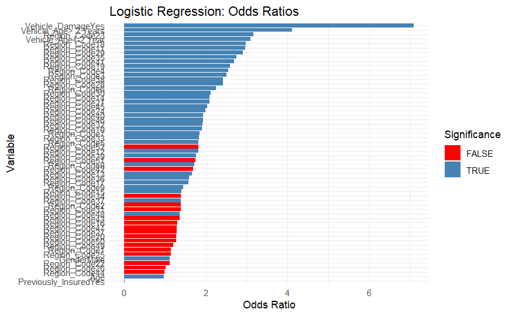

```r
coefs <- summary(logistic_backward)$coefficients
coefs_df <- data.frame(Variable = rownames(coefs),
                       Estimate = coefs[, "Estimate"],
                       p_value = coefs[, "Pr(>|z|)"])
coefs_df <- coefs_df[coefs_df$Variable != "(Intercept)", ]
coefs_df$OddsRatio <- exp(coefs_df$Estimate)
coefs_df$Significance <- coefs_df$p_value < 0.05

library(ggplot2)

ggplot(coefs_df, aes(x = reorder(Variable, OddsRatio), y = OddsRatio, fill = Significance)) +
  geom_col() +
  coord_flip() +
  labs(title = "Logistic Regression: Odds Ratios",
       x = "Variable", y = "Odds Ratio") +
  scale_fill_manual(values = c("red", "steelblue")) +
  theme_minimal()
```

4. Random Forest Training:

```r
library(randomForest)
rf_model <- randomForest(Target ~ .,
                         data = train_split,
                         ntree = 200,
                         mtry = floor(sqrt(ncol(train_split) - 1)),
                         importance = TRUE)

predictions_rf <- predict(rf_model, newdata = test_split)
evaluate_model(test_split$Target, predictions_rf)
```

```
Confusion Matrix and Statistics

          Reference
Prediction     0     1
         0 10111  1439
         1  3169  4732

               Accuracy : 0.7631
                 95% CI : (0.7571, 0.7691)
    No Information Rate : 0.6827
    P-Value [Acc > NIR] : < 2.2e-16

                  Kappa : 0.4913

 Mcnemar's Test P-Value : < 2.2e-16

            Sensitivity : 0.7668
            Specificity : 0.7614
         Pos Pred Value : 0.5989
         Neg Pred Value : 0.8754
             Prevalence : 0.3173
         Detection Rate : 0.2433
   Detection Prevalence : 0.4062
      Balanced Accuracy : 0.7641

       'Positive' Class : 1
```

this shows how the different variables are important in the decision, how they influence the accuracy and gini

```r
importance(rf_model)
```

```
                             0           1 MeanDecreaseAccuracy MeanDecreaseGini
Gender               0.2404756   3.6433889            3.0432061         352.7480
Age                 32.9819562  15.5307737           50.3543297        3791.4895
Licence_Type        -1.3924922   0.1487054           -0.8774501        1231.8491
Region_Code         30.6425987  10.5813141           34.1910010        3054.6380
Previously_Insured -27.1984027 172.6396090          122.6476292        3980.1389
Vehicle_Age         35.4017465 -18.0531874           30.9090376         998.5753
Vehicle_Damage     -62.0452119 133.1502479           84.7455147        4801.0113
Annual_Premium      14.8517841  -3.1735061           12.4654476        3586.3664
Seniority            0.9435142  -0.4002155            0.3290526        3954.7673
```

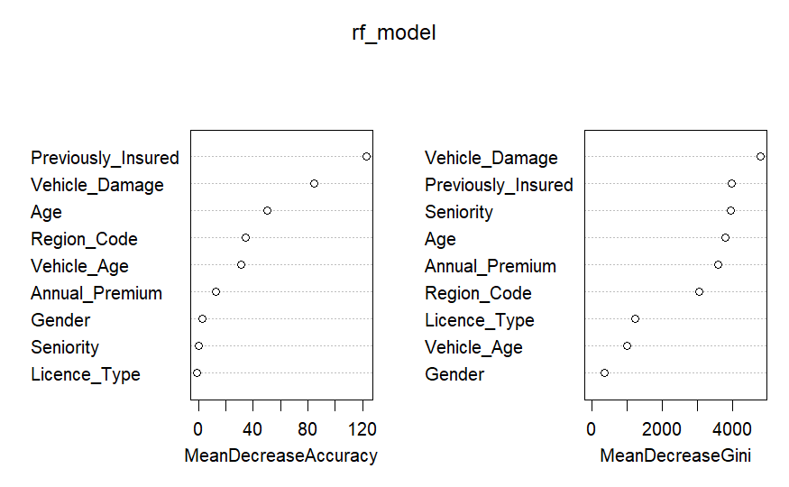

```r
varImpPlot(rf_model)
```

```r
library(DT)
library(DT)

data <- data.frame(
  Változó = c("Age", "Gender", "Region Code"),
  Koeficiensek = c(0.25, -0.5, 0.75),
  P_Value = c(0.03, 0.01, 0.20)
)
datatable(data,
          options = list(pageLength = 5, editable = TRUE))
```

|  | Változó | Koeficiensek | P_Value |
| --- | --- | --- | --- |
| 1 | Age | 0.25 | 0.03 |
| 2 | Gender | -0.5 | 0.01 |
| 3 | Region Code | 0.75 | 0.2 |

```r
library(gt)
```

```r
library(gt)

adatok <- data.frame(
  Metric = c("Accuracy", "Sensitivity", "Precision"),
  Definition = c(
    "Shows the proportion of all predictions (both accepted and rejected) that were correct.",
    "Out of all real acceptances, how many were correctly predicted as accepted.",
    "Out of all cases predicted as accepted, how many were actually accepted."
  ),
  Decision_Tree = c("77%", "73%", "61%"),
  Logistic_Regression = c("75%", "69%", "60%"),
  Random_Forest = c("76%", "76%", "60%")
)

adatok %>%
  gt() %>%
  tab_header(
    title = "Comparing the Performance of Different Models with Definitions"
  ) %>%
  tab_style(
    style = cell_fill(color = "lightgreen"),
    locations = cells_body(
      columns = vars(Random_Forest)
    )
  ) %>%
  tab_style(
    style = list(
      cell_text(weight = "bold"),
      cell_fill(color = "lightgrey")
    ),
    locations = cells_column_labels(everything())
  ) %>%
  cols_label(
    Metric = "Metrics",
    Definition = "Definition",
    Decision_Tree = "Decision Tree",
    Logistic_Regression = "Logistic Regression",
    Random_Forest = "Random Forest"
  ) %>%
  cols_width(
    Definition ~ px(350) # szélesebb legyen a definíciós oszlop
  )
```

Comparing the Performance of Different Models with Definitions

| Metrics | Definition | Decision Tree | Logistic Regression | Random Forest |
| --- | --- | --- | --- | --- |
| Accuracy | Shows the proportion of all predictions (both accepted and rejected) that were correct. | 77% | 75% | 76% |
| Sensitivity | Out of all real acceptances, how many were correctly predicted as accepted. | 73% | 69% | 76% |
| Precision | Out of all cases predicted as accepted, how many were actually accepted. | 61% | 60% | 60% |

```r
library(gt)

conversion_summary <- data.frame(
  Metric = c("Average Conversion Rate in time sensitive projects", "Conversion Rate With the Model",
             "Minimizing unnecessary resource consumption", "Conversion Rate when time does not matter (according to this database)",
             "Loss of customers if time matters", "Using the model this loss is decreasing"),
  Value = c("10%", "⬆️ 60%", "🔽", "30%", "around 66%", "🔽 to a maximum of 24%")
)

conversion_summary %>%
  gt() %>%
  tab_header(
    title = "Why choose the model?"
  ) %>%
  tab_style(
    style = list(
      cell_text(weight = "bold", color = "forestgreen", size = "large")
    ),
    locations = cells_body(
      columns = vars(Value),
      rows = 2
    )
  ) %>%
  tab_style(
    style = cell_text(color = "darkred"),
    locations = cells_body(
      columns = vars(Value),
      rows = grepl("66%", conversion_summary$Value)
    )
  ) %>%
  tab_style(
    style = cell_text(color = "forestgreen"),
    locations = cells_body(
      columns = vars(Value),
      rows = grepl("24%", conversion_summary$Value)
    )
  ) %>%
  cols_label(
    Metric = "",
    Value = ""
  ) %>%
  cols_align(
    align = "center",
    columns = everything()
  ) %>%
  tab_options(
    table.width = pct(50),
    table.align = "center"
  )
```

Why choose the model?

| Average Conversion Rate in time sensitive projects | 10% |
| --- | --- |
| Conversion Rate With the Model | ⬆️ 60% |
| Minimizing unnecessary resource consumption | 🔽 |
| Conversion Rate when time does not matter (according to this database) | 30% |
| Loss of customers if time matters | around 66% |
| Using the model this loss is decreasing | 🔽 to a maximum of 24% |

```r
rmarkdown::render("mandatory_vehicle_insurance_models.Rmd", output_format = "html_document")
```